# Data Carpentry - additional R exercises

## Quantitative proteomics statistical results

1. [Download](https://uclouvain-cbio.github.io/2019-05-20-UCLouvain/data/prot.csv) and load the `prot.csv` file into R.
2. Produce a histogram of p-value. [Discuss](http://varianceexplained.org/statistics/interpreting-pvalue-histogram/) the distribution of these p-values.
3. Produce a *volcano plot*, showing the log2 fold-change along the x axis and -log10 of the adjusted p-value along the y axis. Discuss.
4. Produce an *MA plot*, showing the average intensity (over all samples) along the x axis, and the log2 fold-change along the y axis. Discuss.

```r
prot <- read_csv("./data/prot.csv")
```

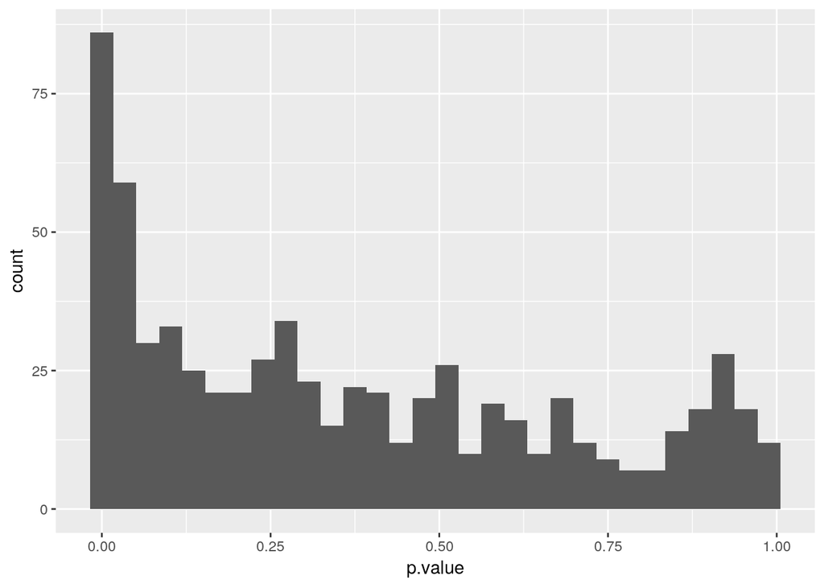

```r
ggplot(prot, aes(x = p.value)) +
    geom_histogram()
```

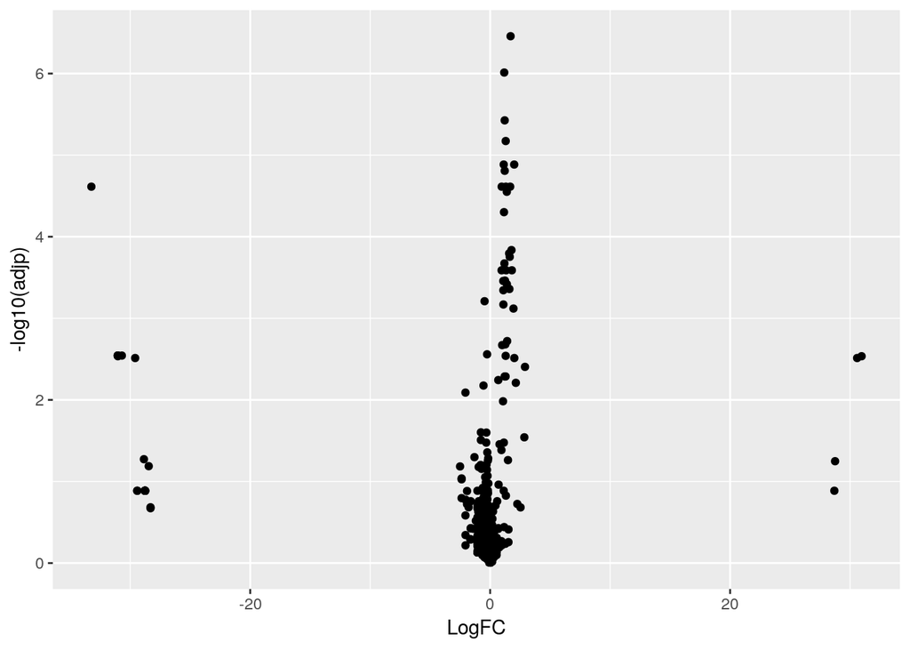

```r
ggplot(prot, aes(x = LogFC,
                 y = -log10(adjp))) +
             geom_point()
```

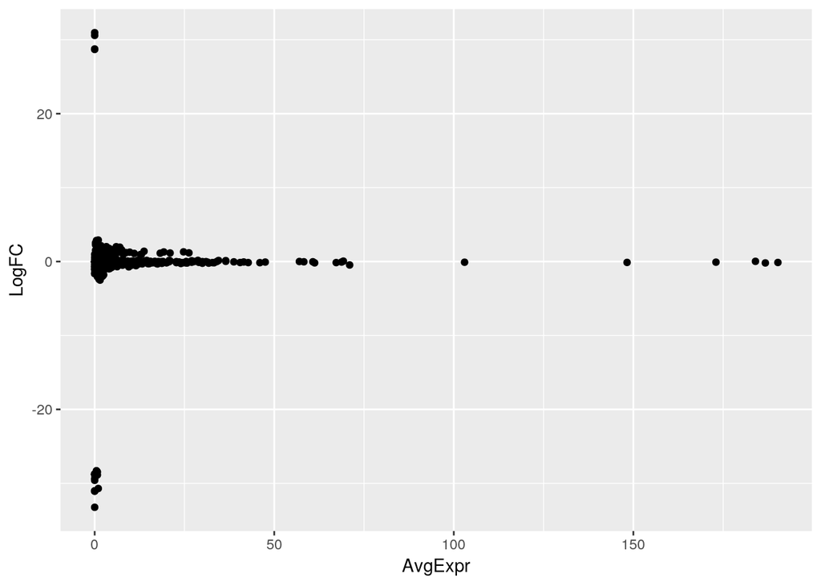

```r
ggplot(prot, aes(x = AvgExpr,
                 y = LogFC)) +
             geom_point()
```